# Homework #9 - Solution

#### 8 pts total

## Problem 1

## A - 1pt

load [this dataset](http://hompal-stats.wabarr.com/datasets/DIK-scap.txt) on scapula morphology in Pan, Homo and Gorilla, and the Dikika fossil child. Details on this data can be found in [Alemseged et al, 2006](http://www.nature.com/nature/journal/v443/n7109/full/nature05047.html)

```r
scap <- read.table("http://hompal-stats.wabarr.com/datasets/DIK-scap.txt", header=TRUE)
```

## B - 1pt

Calculate the natural log of all the numeric variables

```r
# log all the measurements, excluding the first row
scap[,-1] <- log(scap[,-1])
```

## C - 1pt

Make a subset of the data including only the extant species (G, H, or P, representing Gorilla, Homo and Pan), excluding the Dikika fossil (D).

```r
subset_scap <- dplyr::filter(scap, Taxon != "D")
```

## D - 1pt

Perform a discriminant function analysis on the data. Which variable has the strongest loading on LD1?

```r
library(MASS)
DFA <- lda(x=subset_scap[,-1], grouping=subset_scap$Taxon)
DFA
```

```
## Call:
## lda(subset_scap[, -1], grouping = subset_scap$Taxon)
##
## Prior probabilities of groups:
##         G         H         P
## 0.3417722 0.2911392 0.3670886
##
## Group means:
##       SSFB     TOTB     SSFL     ISFB      MOL      SPL     ISFL    PSSFB
## G 4.213874 4.816231 4.201309 4.225263 4.522603 4.713122 4.621712 3.854627
## H 3.260568 4.345349 3.657431 4.106738 3.980998 4.178805 4.049559 3.072758
## P 3.897599 4.518186 3.918844 3.867818 4.182304 4.398842 4.423187 3.408756
##      PISFB      GFL      GFB
## G 4.210353 3.391814 3.005870
## H 4.100065 3.030641 2.631709
## P 3.635822 3.088464 2.741510
##
## Coefficients of linear discriminants:
##               LD1         LD2
## SSFB  -10.3161467  -4.2460350
## TOTB   -2.8354310  -0.7961162
## SSFL   11.1350006  10.0673675
## ISFB   -3.2755157  12.0736770
## MOL    -4.4411419 -17.8401790
## SPL     0.9830035   6.3123756
## ISFL   -4.9539689   5.1112446
## PSSFB   0.6174285  -4.2105436
## PISFB  13.1771010 -11.5279013
## GFL    -1.2594441  -0.4065495
## GFB     1.7064927   3.4084295
##
## Proportion of trace:
##    LD1    LD2
## 0.8095 0.1905
```

`PISFB` has the strongest loading

## E - 2 points

Make a beautiful plot (using ggplot) of LD1 versus LD2. Hint: to get the LD scores, use the `predict()` function on your discriminant function analysis model object, as shown in class.

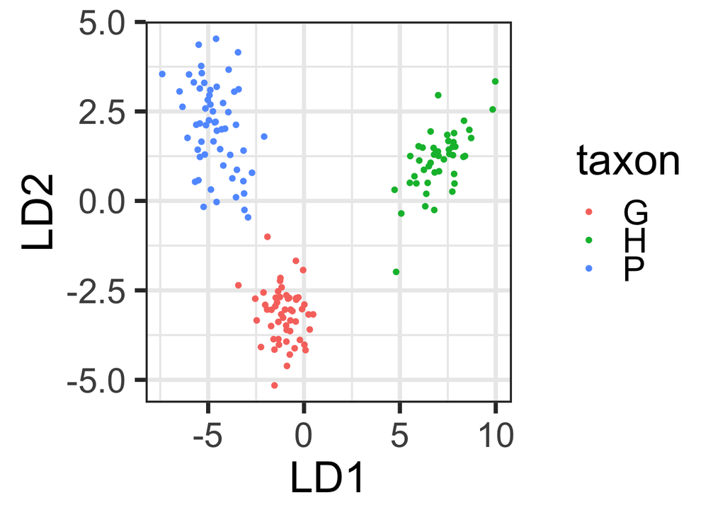

```r
library(ggplot2)
forPlot <- data.frame(predict(DFA)$x, taxon=subset_scap$Taxon)
LDAscatter <- ggplot(forPlot, aes(x=LD1, y=LD2)) + geom_point(aes(color=taxon))
LDAscatter
```

## F - 2 pt

Plot the Dikika fossil on the DFA plot.

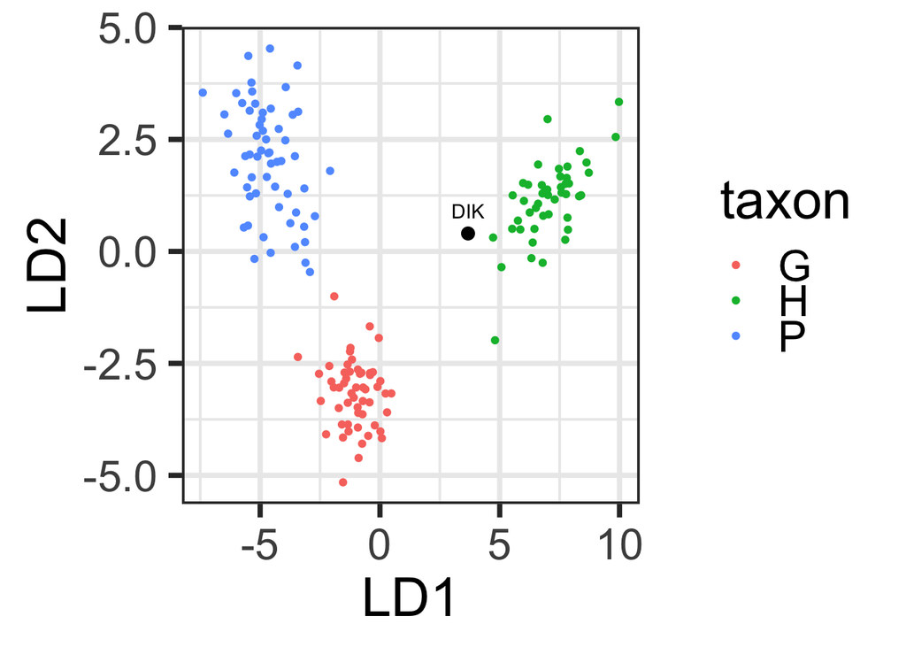

```r
dikika <- dplyr::filter(scap, Taxon=="D")
DIK_dfa <- predict(DFA, newdata = dikika[,-1])
DIK_plot <- data.frame(DIK_dfa$x, label="DIK")

LDAscatter +
  geom_point(data=DIK_plot,size=3) +
  geom_text(data=DIK_plot,aes(x=LD1, y=LD2 + 0.5, label=label))
```

## G - bonus point

The easiest way I know how to do this is to use the `do()` function in `dplyr`. Note: in the code below the dot (`.`) represents the dataframe passed from the `group_by` function through the pipe (actually it represents one dataframe per group, and `do()` will do something to each one of these dataframes). Usually in `dplyr`, the dataframe being passed by the pipe doesn’t need to be explicitly referenced, it is passed on as the first positional argument. `do()` gives you complete flexibility to do almost anything, but you have to explcitly tell it where to put the dataframe with the dot.

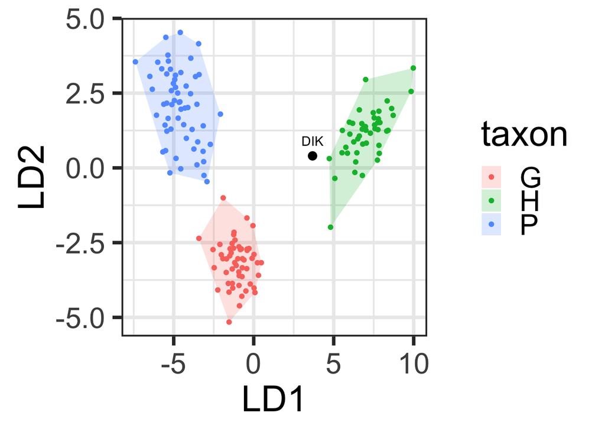

```r
chulls <- forPlot %>%
  group_by(taxon) %>%
  do(.[chull(.[,c("LD1", "LD2")]), c("LD1", "LD2")])


LDAscatter +
  geom_polygon(data=chulls,
               mapping=aes(x=LD1, y=LD2, group=taxon, fill=taxon),
               alpha=0.2) +
  geom_point(data=DIK_plot,size=3) +
  geom_text(data=DIK_plot,aes(x=LD1, y=LD2 + 0.5, label=label))
```